# Module 1 final exam assignment

Kenneth Jørgensen and Mads-Peder Daugaard

1 oct 2018

# How are the Taiwanese servicing their credit card debt?

This notebook will explore what characterizes Taiwanese credit card debt holders. The data has been downloaded from kaggele at: https://www.kaggle.com/uciml/default-of-credit-card-clients-dataset.

We would like to acknowledge Lichman, M. (2013). UCI Machine Learning Repository [http://archive.ics.uci.edu/ml]. Irvine, CA: University of California, School of Information and Computer Science.

The original dataset can be found at the UCI Machine Learning Repository: https://archive.ics.uci.edu/ml/datasets/default+of+credit+card+clients

## Problem statement

By exploring the some demographic data matched with data on credit card debt it is possible to get, at least an rough, idea of the kind od people collecting credit card debt; what is their educational backgrond? How old are they? What is their marritial status? And at least are they male or female?

We are going to run both a regression problem and a classification problem. The regression problem will be on predicting the age of a credit card debt holder. The regression problem will not be very extensive since it is not the main focus point of this notebook.

The classification problem will be on predicting whether a credit card debt holder default on the credit or not. For the classification problem we will run several models since this will be the focal point of this notebook. If you browse through some of the links above you will see that the use of the dataset have been used for classification problems (see also the collecting the data for the purpose of the dataset).

## Collecting the data

The credit card issuer has gathered information on 30000 customers. The dataset contains information on 24 variables, including demographic factors, credit data, history of payment, and bill statements of credit card customers from April 2005 to September 2005, as well as information on the outcome: did the customer default or not? We had problems reading the full dataset with 30000 observations therefore we have done some datacleaning before loading the data. We removed values from pay_0 through pay_6 with values of -2 and 0 since these have no assigned values. This leaves us with 4057 observations.

This gives insight into whether a customer is likely to default or not.

## Obtaining the data

```r
rm(list=ls())
```

Loading some useful packages.

```r
library(tidyverse) # loads the whole tidyverse, including dplyr, readr, ggplot, etc
library(data.table) # loads the data.table package, in case you use the fread()
library(magrittr) # forward pipe operator
```

Loading the data from the folder.

```r
credit_df <- fread("credit_data.csv", header = TRUE, check.names = TRUE, data.table = FALSE)
```

## Basic cleaning

Making all small caps for easier furher coding.

```r
colnames(credit_df) <- tolower(colnames(credit_df))
```

Removing variables to only show variables once.

```r
credit_df <- credit_df[,!duplicated(colnames(credit_df))]
```

Individual id should only appear once.

```r
credit_df <- credit_df %>%
  distinct(id, .keep_all = TRUE)
```

Row names are added.

```r
rownames(credit_df) <- credit_df[,"id"]
```

## Exploration

Visualizing some relationships from the data.

Lets tak a first glimpse at how many are defaulting.

```r
credit_df %>%
  group_by(default.payment.next.month) %>%
  count()
```

| default.payment.next.month | n |
| --- | --- |
| 0 | 2620 |
| 1 | 1437 |

Looks like about 1/3 of credit card debt holders default on their loans. Variable value #1 means defaulting.

Now lets dig deeper and take a look at how the amount of credit is distributed on age and compared between the sexes.

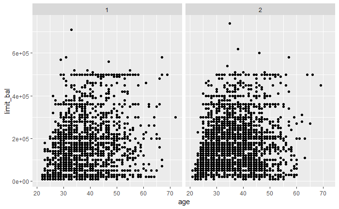

```r
library(ggplot2)
library(gapminder)
library(dplyr)
# Comparing age and limit balance
ggplot(credit_df, aes(x = age, y = limit_bal)) +
  geom_point() +
  facet_wrap(~sex)
```

Nothing springs to mind looking at debt paired with age for men and women. It looks like that men and women take on about the same amount of debt at roughly the same time in their lifes.

Now lets take a look at what your educational background means for the amount of credit you build up from your credit card.

What is the average debt and age in each education bracket?

```r
credit_df %>%
  group_by(education) %>%
    summarize(mean_debt = mean(limit_bal), mean_age = mean(age))
```

| education | mean_debt | mean_age |
| --- | --- | --- |
| 1 | 214257.7 | 35.56354 |
| 2 | 144500.9 | 35.81903 |
| 3 | 129684.0 | 41.04265 |
| 4 | 248000.0 | 34.60000 |
| 5 | 170833.3 | 35.66667 |
| 6 | 204000.0 | 44.00000 |

Lets try to illustrate with absolute values.

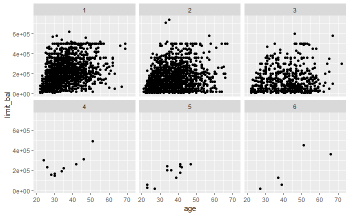

```r
ggplot(credit_df, aes(x = age, y = limit_bal)) +
  geom_point() +
  facet_wrap(~education)
```

This shows the amount of people at each educational level. Most people with a credit card are highly educated. It looks like people with higher educational level have a lot more credit card debt people with at least high school and up collect much more debt.

So how many people are in trouble in given months?

```r
par(mfrow = c(2, 3))
hist(credit_df$pay_0, main="payment status September")
hist(credit_df$pay_2, main="payment status August")
```

```r
hist(credit_df$pay_3, main="payment status July")
hist(credit_df$pay_4, main="payment status June")
```

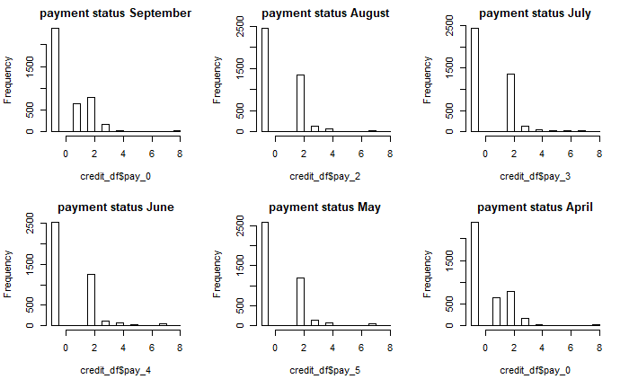

```r
hist(credit_df$pay_5, main="payment status May")
hist(credit_df$pay_0, main="payment status April")
```

According to the histogram most people repay their credit card debt on time. However, at the same time it looks like there a large relatively large group of people who are consistently behind about 2 months.

How many people in different demographic groups?

```r
par(mfrow = c(1, 3))
hist(credit_df$sex, main="Sex")
hist(credit_df$education, main="Education")
```

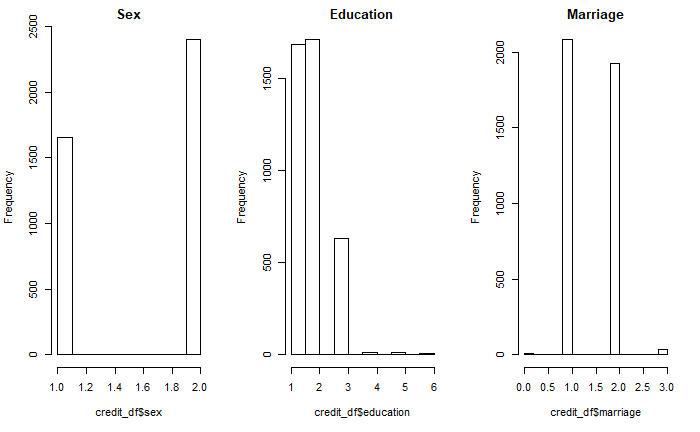

```r
hist(credit_df$marriage, main="Marriage")
```

This histogram shows the demographic structure of the groups having loans. Looking at the first histogram it shows the amount of women is higher than the amount of men holding credit card debt.

Noticable for the second histogram is the fact that the people with the highest educations (1 representing graduate school, 2 representing university) are the categories with the highest amount of people obtaining debt.

Looking at the last histogram it shows us that there’s a little difference between married and single people.

### Dimentionality reduction.

Now we will look at Principal Component Analysis (PCA) which takes possible correlated variables and turn them into linear uncorrelated variables.

```r
library(FactoMineR)
library(factoextra)
res.pca <- PCA(credit_df, scale.unit = TRUE, graph = FALSE)
```

Now we will illustrate what component and to what degree that component explains the variance using a scree plot.

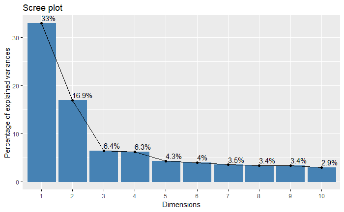

```r
fviz_screeplot(res.pca,
               addlabels = TRUE,
               ncp = 10,
               ggtheme = theme_gray())
```

Lets see if we can use our ndimentional reductions to differentiate groups based on the whether an individual will default payment next month or not.

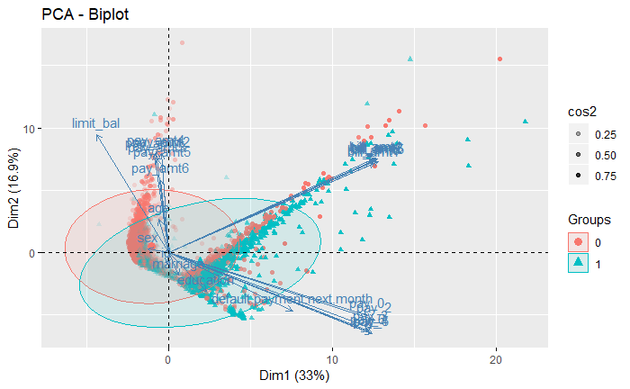

```r
credit_df %<>%
  mutate(default = ifelse(default.payment.next.month > mean(default.payment.next.month), TRUE, FALSE))
fviz_pca_biplot(res.pca,
                alpha.ind = "cos2",
                geom = "point",
                habillage = factor(credit_df$default.payment.next.month),
                addEllipses = TRUE,
                ggtheme = theme_gray())
```

So we get two clusters based on default payment. There are some overlapping between the groups but it looks like there is a strong devision from upper left to lower right.

Now lets move on to do some unsupervised machine learning using clustering.

## Clustering

Now that we have some basic relationships illustrated it is time to start clustering to see how the individuals group together. We will use k-means clustering.

First up lets take a look at how many clusters we need to make this happen.

So how many clusters are we going to use?

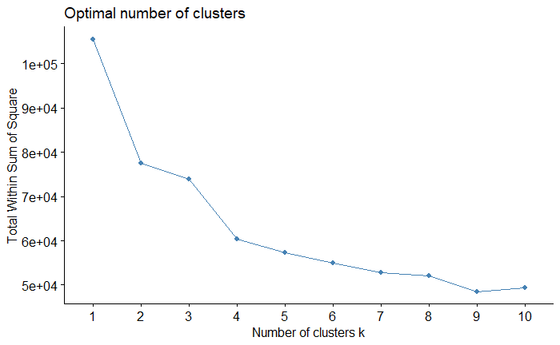

```r
fviz_nbclust(scale(credit_df),
            kmeans,
            method = "wss")
```

We will go with 3 clusters.

Now setting the right row names otherwise the next dplyr pipe will delete them again.

```r
rownames(credit_df) <- credit_df %>% pull(id)
```

Only choosing the data we want to cluster. In this case we use all the variables from the data set.

```r
km <- kmeans(scale(credit_df), centers = 3, nstart = 20)
```

```r
km.credit <- kmeans(credit_df %>% select(-id) %>% scale(), centers = 3)
```

Now visualize the data.

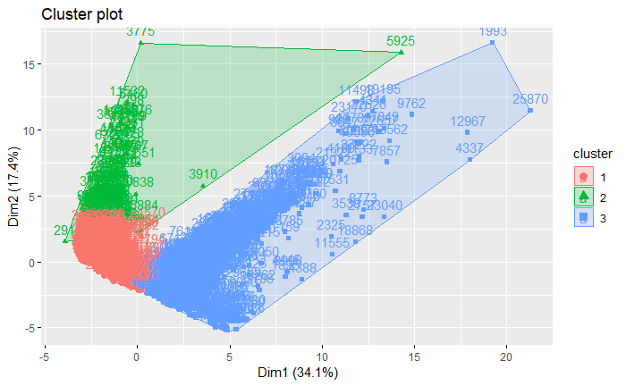

```r
library(factoextra)
fviz_cluster(km.credit,
             data = credit_df %>% select(-id) %>% scale())
```

Now binding to original credit data.

Binding to original data.

```r
credit_df <- credit_df %>%
  bind_cols(cluster = km.credit$cluster)
```

Now lets take a quick look at how many individuals are in the different clusters.

```r
credit_df %>%
  group_by(cluster) %>%
  count()
```

| cluster | n |
| --- | --- |
| 1 | 2492 |
| 2 | 166 |
| 3 | 1399 |

So most people in cluster 1 followed by cluster 3 and least people ind cluster 2. Lets take a look what characterizes cluster 1 - and also the other two clusters.

```r
credit_df %>%
  bind_cols(cluster = km$cluster) %>%
  group_by(cluster) %>%
  mutate(n = n()) %>%
  summarise_all(funs(mean))
```

| cluster | id | limit_bal | sex | education | marriage | age | pay_0 | pay_2 | pay_3 | pay_4 | pay_5 | pay_6 | bill_amt1 | bill_amt2 | bill_amt3 | bill_amt4 | bill_amt5 | bill_amt6 | pay_amt1 | pay_amt2 | pay_amt3 | pay_amt4 | pay_amt5 | pay_amt6 | default.payment.next.month | default | cluster1 | n |
| --- | --- | --- | --- | --- | --- | --- | --- | --- | --- | --- | --- | --- | --- | --- | --- | --- | --- | --- | --- | --- | --- | --- | --- | --- | --- | --- | --- | --- |
| 1 | 14289.60 | 203434.99 | 1.627207 | 1.668138 | 1.472311 | 36.77568 | -0.7343499 | -0.7552167 | -0.7459872 | -0.8447030 | -0.9040931 | -0.8451043 | 4890.406 | 4256.428 | 3942.549 | 3916.99 | 3984.559 | 4246.128 | 4034.844 | 3854.942 | 3870.427 | 3886.089 | 4062.685 | 4226.487 | 0.17817014 | 0.17817014 | 1.013242 | 2492 |
| 2 | 13272.69 | 352289.16 | 1.542169 | 1.481928 | 1.397590 | 40.43373 | -0.8614458 | -0.9036145 | -0.8915663 | -0.9638554 | -0.9457831 | -0.9277108 | 27913.548 | 35628.584 | 35316.867 | 40757.38 | 35851.892 | 34626.422 | 33249.855 | 33288.187 | 39390.024 | 34254.301 | 34057.452 | 28729.398 | 0.06626506 | 0.06626506 | 1.036145 | 166 |
| 3 | 14391.28 | 93309.51 | 1.536812 | 1.955683 | 1.529664 | 35.64260 | 1.9442459 | 2.2894925 | 2.3638313 | 2.4453181 | 2.4281630 | 2.3395282 | 52070.565 | 52822.754 | 53416.219 | 53783.32 | 54111.482 | 54036.124 | 2420.769 | 2529.516 | 2200.287 | 2223.132 | 2028.568 | 2440.769 | 0.70192995 | 0.70192995 | 2.145104 | 1399 |

Remember this is average scores for the given variables.

Most people in cluster 1 with an average credit card debt of 203.435 NTD. More women than men (closer to 2 than 1). In cluster 1 people are most likely to be married and for all months they are on average likely to be on point with their repayment scheme and are not very likely to default (closer to 0 than 1).

Cluster 3 is most likely to default which makes sense since people in that cluster have the largest bill throughout all months and they are on average a little more than two months behind on their payments in all months.

Now lets take a look at individuals based on different restrictions being met or not.

```r
credit_df %>%
  drop_na() %>%
  arrange() %>%
  group_by(id, default.payment.next.month) %>%
  summarize(total = n(),
            gender = mean(sex == 1), #Man or woman?
            education = mean(education < 3), #What about the highly educated?
            marriage = mean(marriage == 1)) %>%
  ungroup()
```

| id | default.payment.next.month | total | gender | education | marriage |
| --- | --- | --- | --- | --- | --- |
| 12 | 0 | 1 | 0 | 1 | 0 |
| 22 | 1 | 1 | 0 | 1 | 1 |
| 29 | 0 | 1 | 0 | 0 | 1 |
| 31 | 0 | 1 | 0 | 1 | 0 |
| 49 | 0 | 1 | 1 | 1 | 0 |
| 59 | 0 | 1 | 0 | 1 | 0 |
| 63 | 1 | 1 | 1 | 1 | 0 |
| 68 | 0 | 1 | 0 | 1 | 0 |
| 71 | 0 | 1 | 1 | 1 | 0 |
| 72 | 1 | 1 | 1 | 1 | 0 |

[output cut: 990 more lines]

Please be adviced that since we have now set up some restriction of e.g. gender, 1 means the condition is met and the id is male but 0 means condition is not met and therefore the person is a woman (not = 2 here as in the data frame).

## Machine learning

### Regression

So for this regreesion problem we are trying to predict age. Why is that intersting? Well, it is interesting to know if it is possible to predict when you are likely to take on credit card debt. That way it is possibly easier for you to avoid taking on (expensive) credit card debt in the first place. If you are in your mid twenties using this prediction will allow you to get an idea of when to be aware of your consumption and maybe even save up for your future expenses you would otherwise finance with credit card.

We tried different regressions models and found elastic net to give the best results.

First up is setting training and test sets using af 80/20 split.

```r
library(caret)
index <- createDataPartition(y = credit_df %>% pull(age), p = 0.8, list = FALSE)
training <- credit_df[index,]
test <- credit_df[-index,]
```

Some further preprocessing is made.

```r
library(recipes)
reci <- recipe(age ~ ., data = training) %>%
  step_center(all_numeric(), -all_outcomes()) %>%
  step_scale(all_numeric(), -all_outcomes()) %>%
  prep(data = training)
```

We will now allot the outcom and predictors in training and test set.

```r
# Training: split in y and x
x_train <-bake(reci, newdata = training) %>% select(-age)
y_train <- training %>% pull(age)
# test: split in y and x
x_test <-bake(reci, newdata = test) %>% select(-age)
y_test <- test %>% pull(age)
```

Remove what we dont need anymore.

```r
rm(index, reci)
```

Crossvalidating the training data.

Setting number of crosvalidations (CV) to 10.

```r
ctrl.reg <- trainControl(method = "cv",
                           number = 10)
```

The best model fron the extended verison was the elastic net.

The elastic net model has the functional form of af generilized linear model meaning it is a flexible generalization of a linear model which means the magnitude of the variance to be a function of its own prediction.

```r
tune.glmnet = expand.grid(alpha = seq(0, 1, length = 5),
                          lambda = seq(0, 1, length = 5))
```

Fitting the model.

```r
fit.glmnet <- train(x = x_train,
                    y = y_train,
                    trControl = ctrl.reg,
                    method = "glmnet", family = "gaussian",
                    tuneGrid = tune.glmnet)
```

[output not shown]

What are the models characteristics?

```r
fit.glmnet
```

```
glmnet

3247 samples
  26 predictor

No pre-processing
Resampling: Cross-Validated (10 fold)
Summary of sample sizes: 2923, 2922, 2922, 2921, 2922, 2924, ...
Resampling results across tuning parameters:

  alpha  lambda  RMSE      Rsquared   MAE
  0.00   0.00    7.865783  0.2618756  6.189804
  0.00   0.25    7.865783  0.2618756  6.189804
  0.00   0.50    7.865654  0.2620344  6.192870
  0.00   0.75    7.866344  0.2623899  6.203613
  0.00   1.00    7.868980  0.2626117  6.215635
  0.25   0.00    7.881571  0.2594460  6.181060
  0.25   0.25    7.855349  0.2642145  6.179747
  0.25   0.50    7.860385  0.2645238  6.200016
  0.25   0.75    7.873123  0.2639854  6.227117
  0.25   1.00    7.892131  0.2626226  6.256961
  0.50   0.00    7.881490  0.2594601  6.181042
  0.50   0.25    7.856558  0.2645245  6.186131
  0.50   0.50    7.878044  0.2626714  6.227019
  0.50   0.75    7.908172  0.2598751  6.273671
  0.50   1.00    7.942660  0.2569945  6.319697
  0.75   0.00    7.881542  0.2594515  6.181039
  0.75   0.25    7.862303  0.2640408  6.197814
  0.75   0.50    7.900693  0.2598240  6.257912
  0.75   0.75    7.949555  0.2547410  6.320946
  0.75   1.00    8.016719  0.2460662  6.393280
  1.00   0.00    7.881529  0.2594502  6.181061
  1.00   0.25    7.872423  0.2626918  6.212037
  1.00   0.50    7.925504  0.2567550  6.288623
  1.00   0.75    8.007610  0.2457031  6.378366
  1.00   1.00    8.084610  0.2356702  6.460047

RMSE was used to select the optimal model using the smallest value.
The final values used for the model were alpha = 0.25 and lambda = 0.25.
```

The model was used for predicting the age.

```r
pred.glm <- predict(fit.glmnet, newdata = x_test)
```

Calculating a mean.

```r
head(pred.glm, 25)
```

```
 [1] 32.26218 39.60837 38.20919 34.68162 38.61258 31.66401 32.75292 38.67217 43.45402 41.37734 39.07487 32.71719 38.47215 38.93977 40.49880 38.00256
[17] 34.80511 39.62620 32.25114 41.30198 23.14736 38.82821 30.73433 30.63017 31.87300
```

This means people are in their 30’s when they take on credit card debt.

### Classification

Next up we present a classification problem where we want to predict wheter an individual default on their credit card debt (TRUE) or not (FALSE).

First off we have to change some variable types to make sure that the code will run and read the default value correct.

```r
str(credit_df$default)
```

```
 logi [1:4057] FALSE TRUE FALSE FALSE FALSE FALSE ...
```

```r
credit_df$default <- as.factor(as.logical(credit_df$default))
```

```r
str(credit_df$default)
```

```
 Factor w/ 2 levels "FALSE","TRUE": 1 2 1 1 1 1 2 1 1 2 ...
```

```r
levels(credit_df$default) <- make.names(levels(factor(credit_df$default)))
```

This short version only shows the best performer: Random Forest.

First up is setting training and test sets using af 80/20 split setting p = .8. It is important to do this to be able to create a model based on training data and then use that model on the test data. It is important to know the test data before hand to make sure how accurate the prediction is. If we did not have the test data we would not have the possiblity to properbly assesst he prediction on new data.

```r
library(caret)
index <- createDataPartition(y = credit_df %>% pull(default), p = 0.8, list = FALSE)
training <- credit_df[index,] %>% select(-default.payment.next.month)
test <- credit_df[-index,] %>% select(-default.payment.next.month)
```

Some further preprocessing is made.

```r
library(recipes)
reci <- recipe(default ~ ., data = training) %>%
  step_center(all_numeric(), -all_outcomes()) %>%
  step_scale(all_numeric(), -all_outcomes()) %>%
  prep(data = training)
```

We will now allot the outcom and predictors in training and test set. This is done to ease the workflow later on.

```r
# Training: split in y and x
x_train <-bake(reci, newdata = training) %>% select(-default)
y_train <- training %>% pull(default)
# test: split in y and x
x_test <-bake(reci, newdata = test) %>% select(-default)
y_test <- test %>% pull(default)
```

Remove what we dont need anymore.

```r
rm(index, reci)
```

Crossvalidating the training data.

Setting number og crosvalidations (CV) to 10.

```r
ctrl.class <- trainControl(method = "cv",
                           number = 10, # Number of CV's
                           classProbs = TRUE, # Include probability of class prediction
                           summaryFunction = twoClassSummary)
```

As seen from the extended version of this notebook the random forest model perfomed best.

```r
library(ranger)
tune.rf <- expand.grid(mtry = round(seq(1, ncol(x_train)-1, length = 3)),
                       min.node.size = c(10, 50, 100),
                       splitrule = c("gini", "extratrees") )

fit.rf <- train(x = x_train,
                y = y_train,
                trControl = ctrl.class,
                metric = "ROC",
                method = "ranger",
                importance = "impurity", # To define how to measure variable importantce (later more)
                num.trees = 25,
                tuneGrid =  tune.rf)
```

[output not shown]

What are the characteristics of the model?

```r
fit.rf
```

```
Random Forest

3246 samples
  25 predictor
   2 classes: 'FALSE.', 'TRUE.'

No pre-processing
Resampling: Cross-Validated (10 fold)
Summary of sample sizes: 2921, 2922, 2921, 2922, 2922, 2921, ...
Resampling results across tuning parameters:

  mtry  min.node.size  splitrule   ROC        Sens       Spec
   1     10            gini        0.8114835  0.8453816  0.6434783
   1     10            extratrees  0.8004399  0.8396514  0.6573913
   1     50            gini        0.8097199  0.8406061  0.6547826
   1     50            extratrees  0.8062757  0.8386990  0.6678261
   1    100            gini        0.8124868  0.8420392  0.6591304
   1    100            extratrees  0.8048338  0.8377444  0.6660870
  12     10            gini        0.7958215  0.8587628  0.6104348
  12     10            extratrees  0.8024688  0.8530075  0.6226087
  12     50            gini        0.8068632  0.8630417  0.6113043
  12     50            extratrees  0.8121488  0.8477649  0.6452174
  12    100            gini        0.8116532  0.8654135  0.6165217
  12    100            extratrees  0.8147032  0.8444224  0.6617391
  24     10            gini        0.7971399  0.8511210  0.5991304
  24     10            extratrees  0.7991419  0.8592208  0.6069565
  24     50            gini        0.8068397  0.8697266  0.6156522
  24     50            extratrees  0.8073209  0.8487195  0.6252174
  24    100            gini        0.8077595  0.8673365  0.6086957
  24    100            extratrees  0.8142343  0.8510891  0.6460870

ROC was used to select the optimal model using the largest value.
The final values used for the model were mtry = 12, splitrule = extratrees and min.node.size = 100.
```

Best models is highest ROC which is with mtry = 12 and min.node.size = 100. That leaves us with a ROC of gini = .8116 and extratrees .8147.

Lets use the model for prediction.

```r
pred.rf <- predict(fit.rf, newdata = x_test)
confusionMatrix(y_test, pred.rf)
```

```
Confusion Matrix and Statistics

          Reference
Prediction FALSE. TRUE.
    FALSE.    451    73
    TRUE.      81   206

               Accuracy : 0.8101
                 95% CI : (0.7814, 0.8366)
    No Information Rate : 0.656
    P-Value [Acc > NIR] : <2e-16

                  Kappa : 0.5821
 Mcnemar's Test P-Value : 0.5727

            Sensitivity : 0.8477
            Specificity : 0.7384
         Pos Pred Value : 0.8607
         Neg Pred Value : 0.7178
             Prevalence : 0.6560
         Detection Rate : 0.5561
   Detection Prevalence : 0.6461
      Balanced Accuracy : 0.7930

       'Positive' Class : FALSE.
```

This shows an accuracy of .8101.

Now lets take a look at what the models predict for the test date when it comes to default (TRUE) or not (FALSE)

```r
head(pred.rf, 50)
```

```
 [1] TRUE.  TRUE.  FALSE. FALSE. TRUE.  FALSE. TRUE.  FALSE. FALSE. FALSE. FALSE. TRUE.  FALSE. TRUE.  FALSE. FALSE. FALSE. TRUE.  FALSE. FALSE. TRUE.
[22] FALSE. FALSE. TRUE.  FALSE. TRUE.  FALSE. FALSE. FALSE. FALSE. TRUE.  FALSE. FALSE. FALSE. TRUE.  FALSE. TRUE.  TRUE.  FALSE. FALSE. TRUE.  TRUE.
[43] FALSE. TRUE.  FALSE. TRUE.  FALSE. FALSE. FALSE. FALSE.
Levels: FALSE. TRUE.
```

Luckily it looks like the most of the people with credit card debt are not going to default on their credit card debt. We saw in the beginning of this notebook that about 1/3 of people default on their credit card debt why it makes sense that most people are predicted not not default.

Okay what variables are the models drawing from? Lets take a look at variable importance.

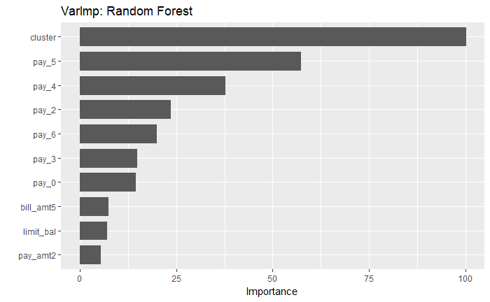

```r
library(vip)
library(ggpubr)
ggarrange(vip(fit.rf) + ggtitle("VarImp: Random Forest"),
          ncol = 1, nrow = 1)
```

So for the model it really looks like the demographic variables are not that important when it comes to classifying whether or not an indidvidual defaults on their credit card debt. The most important variables are the cluster variable and the payment status in given months.

It looks like banks not in advance based on demographic features can determine who is going to default. They have to monitor their clients closely and help them in advance before the repayment scheme goes south.

That’s all folks.